# Copula simulation for SEK

Nils Berndtsson

2021-07-22

I here study the correlation between 2 exchange rates, the SEK/USD and SEK/GBP by using a copula. A copula is a 2-dim distribution function with uniform margins. It is helpful for studying correlation structures between 2 or more random variables. I will be studying the daily exchange rate returns of the aforementioned pairs during the period 2012/01/21 - 2017/01/21. The data is downloaded from Yahoo Finance.

Firstly the data is loaded in:

```r
setwd('/Users/badbo/Desktop/Copula')
library(copula)
usd <- read.csv(file = 'SEKUSD=X.csv')
gbp <- read.csv(file = 'SEKGBP=X.csv')
```

We then transform the daily exchange rate prices of SEK/USD and SEK/GBP to percentage returns.

```r
usd<-diff(as.numeric(usd$Close))/as.numeric(usd$Close)[1:1304]
gbp<-diff(as.numeric(gbp$Close))/as.numeric(gbp$Close)[1:1304]
```

We can now plot the exchange rate return pairs against each other. Some form of positive correlation structure can be seen but it is hard to study it closer with our data’s current scaling.

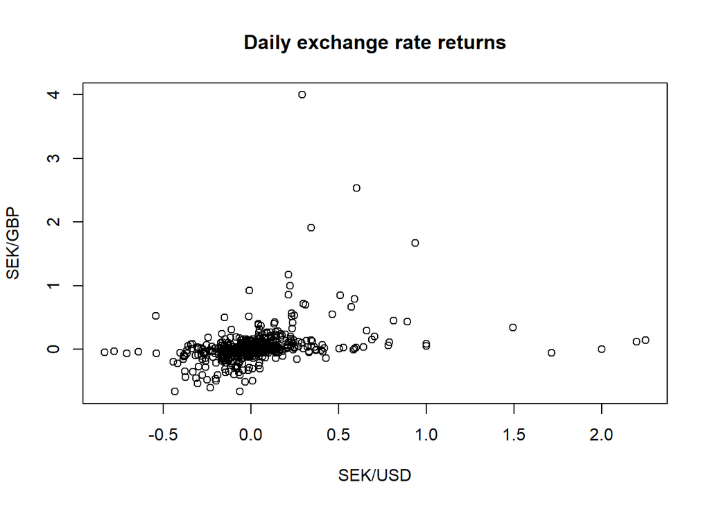

```r
plot(usd,gbp,xlab="SEK/USD",ylab="SEK/GBP",main="Daily exchange rate returns")
```

To simulate a Copula for the exchange rates we need to rescale our 2 exchange rate pairs to variables between 0 and 1. This is done with the pobs function from the copula package. We can now plot the rescaled pairs against each other. The positive correlation structure is now much more clearly visible.

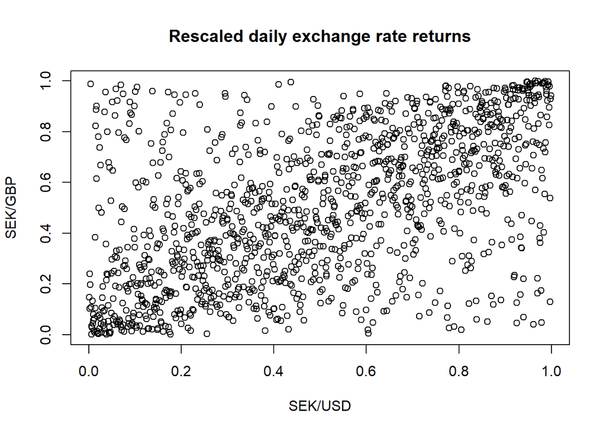

```r
var_a <- pobs(usd)
var_b <- pobs(gbp)

plot(var_a,var_b,xlab="SEK/USD",ylab="SEK/GBP",main="Rescaled daily exchange rate returns")
```

After observing the dependence structure in the last plot a T-Copula is believed to be the most appropriate fit for the data.

We therefore use the copula::fitCopula function to fit a T-copula to our data.

```r
mat<-as.matrix(data.frame(var_a,var_b))

cop <-fitCopula(tCopula(df.fixed = TRUE), mat)
```

We have estimated a T-copula with parameters shown below. We now simulate 1304 random values from this copula to compare with our original data.

```r
cop<-cop@copula
cop
```

```
## t-copula, dim. d = 2
## Dimension:  2
## Parameters (partly fixed, see ':='):
##   rho.1   = 0.5842253
##   df     := 4.0000000
```

```r
n_sim<-1304
t1<-rCopula(n_sim,cop)
```

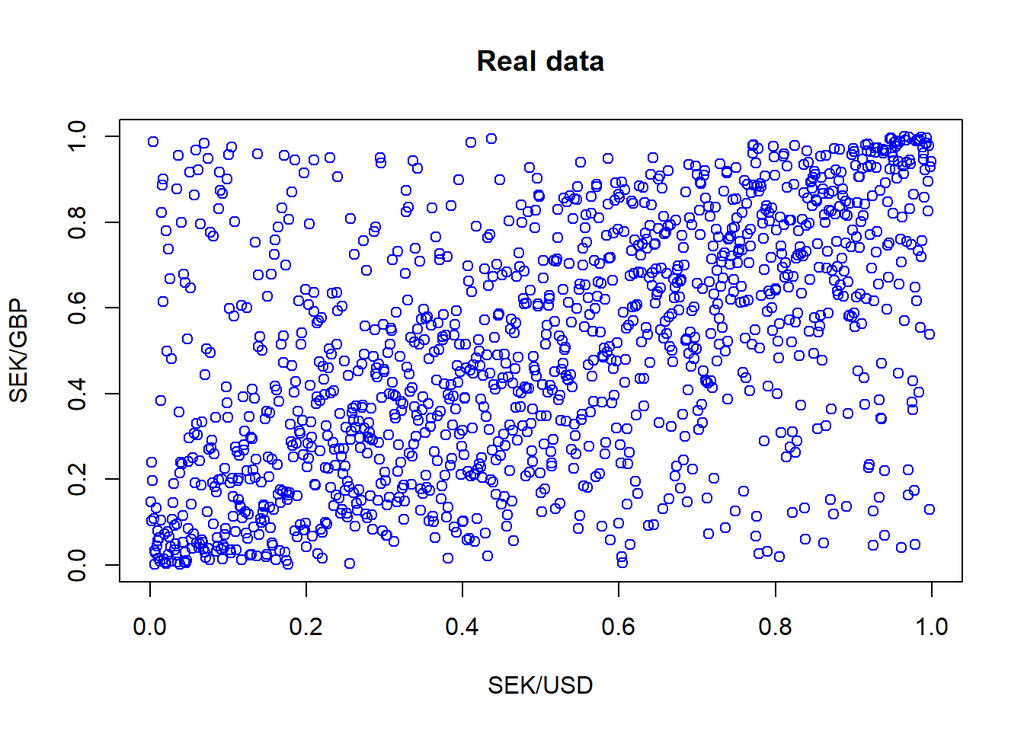

```r
plot(var_a,var_b,xlab="SEK/USD",ylab="SEK/GBP",main="Real data",col="blue")
```

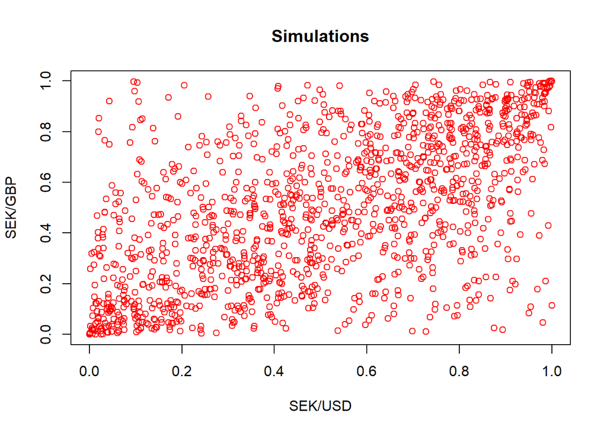

```r
plot(t1[,1],t1[,2],xlab="SEK/USD",ylab="SEK/GBP",main="Simulations",col="red")
```

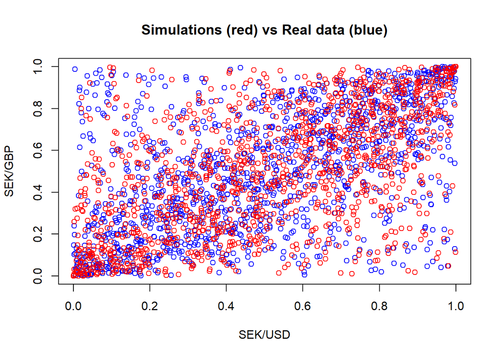

```r
plot(var_a,var_b,col="blue",xlab="SEK/USD",ylab="SEK/GBP",main="Simulations (red) vs Real data (blue)")
points(t1[,1],t1[,2],col="red")
```

Naturally we are not restricted to the 1304 observations in our original sample but can with our T-copula simulated more values to get a clearer picture of the exchange rate pairs dependence structure. We now plot 7000 simulated values.

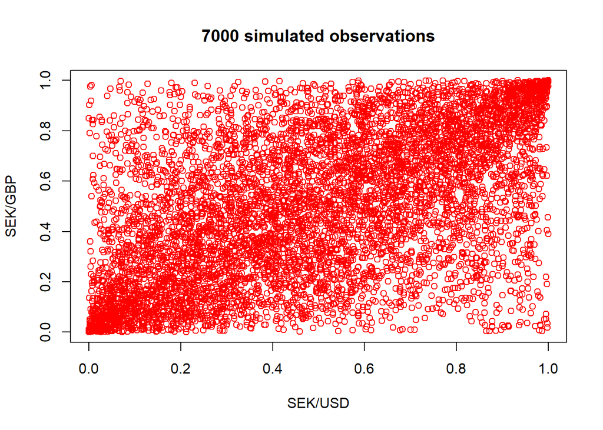

```r
n_sim<-7000

t1<-rCopula(n_sim,cop)
plot(t1[,1],t1[,2],col="red",xlab="SEK/USD",ylab="SEK/GBP",main="7000 simulated observations")
```

Something to note here is that our exchange rate pairs become more correlated when having very high or very low values. The estimated T-copula is useful for estimating upper and lower tail probabilities for the exchange rate pairs. That is the probability that both pairs exceed or are lower than some threshold value. We can for example estimate the following probability:
$$P((X,Y)<(0.95,0.95))$$
as
$$C(x,y)=F(x,y)=P((X,Y)<(x,y))$$
where X = SEK/USD, Y=SEK/GBP and C(x,y) is our estimated T-copula.

This probability is found to be
$$0.9195475$$
when it is estimated below:

[output not shown]

```
## [1] 0.9195475
```

[output not shown]